# Introduction To Bayesian Optimization

## Outline

- Motivation: Why go beyond Supervised and Unsupervised Learning?
- Drawbacks of Supervised Learning algorithms
- Gaussian Process Regression (GPR)
- Bayesian Optimization (BO) using GPR
- Python for BO

## Bayesian Optimization

- Can ML tell us **the next best experiment?**
- Can ML tell us where we have uncertainty in our experimental space?
- Bayesian Optimization allows us to answer both questions!
- Algorithms we have covered thus far lack this ability

```python
import numpy as np
import matplotlib.pyplot as plt

from matplotlib import cm
from mpl_toolkits.mplot3d import Axes3D

def plot_gp(mu, cov, X, X_train=None, Y_train=None, samples=[]):
    X = X.ravel()
    mu = mu.ravel()
    uncertainty = 1.96 * np.sqrt(np.diag(cov))

    plt.fill_between(X, mu + uncertainty, mu - uncertainty, alpha=0.1)
    plt.plot(X, mu, label='Mean')
    for i, sample in enumerate(samples):
        plt.plot(X, sample, lw=1, ls='--', label=f'Sample {i+1}')
    if X_train is not None:
        plt.plot(X_train, Y_train, 'rx')
    plt.legend()

def plot_gp_2D(gx, gy, mu, X_train, Y_train, title, i):
    ax = plt.gcf().add_subplot(1, 2, i, projection='3d')
    ax.plot_surface(gx, gy, mu.reshape(gx.shape), cmap=cm.coolwarm, linewidth=0, alpha=0.2, antialiased=False)
    ax.scatter(X_train[:,0], X_train[:,1], Y_train, c=Y_train, cmap=cm.coolwarm)
    ax.set_title(title)
```

## What does uncertainty mean?

[figure not shown]

## Supervised Learning

- Supervised Machine Learning: Given input, predict (Continuous or Discrete) output

[figure not shown]

- Logisitic Regression, Support Vector Machines, Random Forests etc..
- Problems: These algorithms to not work well with:
  - A large input space
  - Small datasets
- The solution: Gaussian Process Regression

## Gaussian Process Regression

- There are two ways to approach ML:
  - Probablistic Approach: (like Naive Bayes)
  - Non-probablistic approach: (Logistic Regression, Perceptron, SVM, etc.)
- Naive Bayes: Every dimension of input(X) is a Random Variable; y is the target $$P(X|y)=\prod_{n=1}^d P(x_n|y)$$

$X=[x_1,x_2,...,x_d]$

- and we try to find the class, y, that maximixes the function $$P(y|X) = P(x|y)P(y)$$

## Gaussian Processes

- What if we model every datapoint as Random Variable? $$P(y|X) = P(y_1,...,y_N|[x_1,x_2,...,x_N];[w_1,...,w_k])$$ $X: \text{ \{Collection of all the input pairs\}}$, N: number of datapoints, $w_i$: parameters of the ML model

## Probabilities: Joint and Conditional

- A random variable X can be defined given its probability distribution $p(X)$
- Given two random variables X and Y, their joint probability is $p(X,Y)$ and it satisfies $\int_{R} \int_{R}p(x,y)dx dy = 1$ and $p(X,Y) \geq 0$
- Also, given a joint distribution, the conditional probability distribution can be defined as: $$p(X|Y) = \frac{p(X,Y)}{p(Y)}$$
- We can recover the distribution for individual random variables from the joint distribution as, $$p(X) = \int_{R}p(x,y)dy$$

## Example of Coin Toss

- Toss two coins together
- Set of all the outcomes is: $\{HH, TT, HT, TH\}$
- Let's calculate different probabilities in this case
- $P(C_1=H,C_2=H) = P(HH) = P(C_1=H) \cdot P(C_2=H) = 1/2 * 1/2 = 0.25 $
- $P(HH) = P(HT) = P(TH) = P(TT) = \frac{1}{4}$
- $C_1$: Coin 1, $C_2$: Coin 2

## Coin Toss example

- To recover individual distribution:
  $$p(X) = \int_{R}p(x,y)dy$$ $$P(C_1=H) = P(C_1=H,C_2=H)+P(C_1=H, C_2=T) = 1/2$$
- To get the conditional distribution:
  $$p(X|Y) = \frac{p(X,Y)}{p(Y)}$$ $$P(C_2=T|C_1=H) = \frac{P(C_1=H,C_2=T)}{P(C_1=H)} = \frac{P(HT)}{0.5} = \frac{0.25}{0.5} = 0.5$$

## Gaussian Process (GP)

- **Definition**: GP is a collection of random variables (RV) such that the joint distribution of every finite subset of RVs is multivariate Gaussian
- The multivariate Gaussian distribution is defined by a mean vector $\mu$ and a covariance matrix $\Sigma$. We denote this using a simple notation: $N(\mu, \Sigma)$. We call $\Sigma$ co-variance matrix.

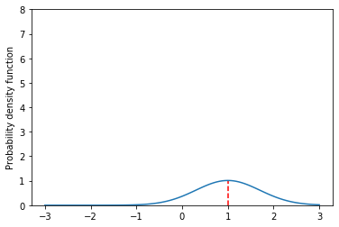

```python
# Normal distribution
import numpy as np

x = np.linspace(-3.,3.,100)
mu = 1
sigma = 0.7
y = 1/np.sqrt(2*sigma**2)*np.exp(-0.5*(x-mu)**2/sigma**2)
plt.plot(x,y)
plt.ylim(0,8)
plt.vlines(mu,0,max(y),'r','dashed')
plt.ylabel('Probability density function')
```

[figure not shown]

- For a multidimensional Gaussian distribution, the entries of $\Sigma$ dictates how fast the decay happens in different directions.

## Latent/Objective Function:

- Goal of Gaussian processes: Learn the underlying multivariate distribution from training data.
- Let *f* be the function we want to optimize: we call it **latent function** or **objective function**: $f(x_n) \rightarrow y_n$
- *f* can be anything: experimental mapping, radioactivity decay, expensive-to-evaluate mathematical function

## Gaussian Process

- A Gaussian process is a random process where the joint distribution of a finite number of these variables $p(f(x1),…,f(xN))$ is itself Gaussian: $$p(f|X)=N(\mu,\Sigma)$$
  where $f=(f(x_1),f(x_2),...,f(x_N)), \mu=(m(x_1),m(x_2),..,m(x_N))$ and $\Sigma_{ij}=\kappa(x_i,x_j)$. **m** is the mean function and $\kappa$ is called a kernel function which is used for capturing how close two input pairs are.
- As we observe new outputs, we improve upon this: prior to posterior

## Kernels

- Recall that in order to set up our distribution, we need to define $\mu$ and $\Sigma$.
- In Gaussian processes it is often assumed that $\mu = 0$
- The key step of Gaussian processes is setting up the covariance matrix $\Sigma$:
  - We do this by evaluating the kernel $\kappa$, pairwise on all the points.
- The kernel receives two points $x,x'\in \mathbb{R}^n$ as an input and returns a similarity measure between those points in the form of a scalar.
- Might have seen this in context of SVMs
- kernels allow similarity measures beyond the standard euclidean distance (L2-distance)
- A few common kernels are shown below:

[figure not shown]

```python
import numpy as np

def kernel(X1, X2, l=1.0, sigma_f=1.0):
    '''
    Isotropic squared exponential kernel. Computes
    a covariance matrix from points in X1 and X2.

    Generating covariance matrix for training data,
    we just give the same input twice to X1 and X2

    Args:
        X1: Array of m points (m x d).
        X2: Array of n points (n x d).

    Returns:
        Covariance matrix (m x n).
    '''
    sqdist = np.sum(X1**2, 1).reshape(-1, 1) + np.sum(X2**2, 1) - 2 * np.dot(X1, X2.T)
    return sigma_f**2 * np.exp(-0.5 / l**2 * sqdist)
```

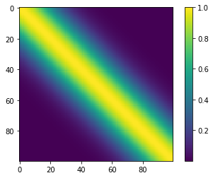

```python
x1 = np.linspace(-3,3,100).reshape(-1,1)
x2 = x1.copy()

outs = kernel(x1,x2)
plt.imshow(outs)
plt.colorbar()
#plt.plot()
```

## The Prior distribution p(f|X)

- From the definition of GPR, $$p(f|X)=N(\mu,\Sigma)$$
  where $f=(f(x_1),f(x_2),...,f(x_N)), \mu=(m(x_1),m(x_2),..,m(x_N))$ and $\Sigma_{ij}=\kappa(x_i,x_j)$.
- **m** is the mean function and $\kappa$ is a kernel function
- Without loss of generality, we assume that means are zeros

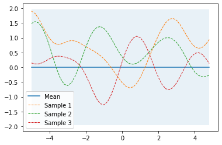

```python
# Finite number of points
X = np.arange(-5, 5, 0.2).reshape(-1, 1)

# Mean and covariance of the prior
mu = np.zeros(X.shape)
cov = kernel(X, X)

# Draw three samples from the prior
samples = np.random.multivariate_normal(mu.ravel(), cov, 3)
# Each sample is a guess of what function looks like!
# Since we haven't observed anything, all of them are equally likely.

# Plot GP mean, confidence interval and samples
plot_gp(mu, cov, X, samples=samples)
```

## Prior probability distribution

- **A GP prior $p(f|X)$ can be converted to a GP posterior $p(f|X,y)$ after observing some data y.**

## Prior to Posterior: incorporating the observations

- By definition of GP, $$P(f|X) = N(\mu,\Sigma)$$ where $f = [f(x_1),...f(x_n)]$ and $X = [x_1,...,x_n]$
- If we observe values of function *f* for some inputs *x*, we now denote the following
  - $X$: Input points at which we made the observations
  - $y$: Evaluation of function *f* at $X$ $\rightarrow$ these are our observations!
  - $X_*$: Points at which we want to know or predict the values
  - $f_*$: The predicted output of the function at $X_*$
- Prior: $$P(f|X) = N(\mu,\Sigma)$$

$$\Sigma=\kappa([X,X_*],[X,X_*])$$

- Thus, we can write, $$P(y,f_*|X,X_*) \rightarrow N(0,[[K_y,K_*],[K^T_*,K_{**}]])$$
- Here, $K_y=\kappa(X,X)$, $K_*=\kappa(X,X_*)$ and $K_{**}=\kappa(X_*,X_*)$
- Using Marginalization and some 4 pages of maths.... $$p(f_*|X_*,X,y) =N(f_*|\mu_*,\Sigma_*)$$
- Where, $$\mu_*=K_*^TK^{-1}_y y$$ $$\Sigma_* = K_{**} - K^T_* K^{-1}_y K_*$$
- An important point to observe: $y_i$ only appears in update of mean vector $\mu$. It doesn't influence the uncertainty $\Sigma$
- Refer to [this](http://www.gaussianprocess.org/gpml/) for a detailed proof of the above relations

```python
from numpy.linalg import inv

def posterior_predictive(X_s, X_train, Y_train, l=1.0, sigma_f=1.0, sigma_y=1e-8):
    '''
    Computes the suffifient statistics of the GP posterior predictive distribution
    from m training data X_train and Y_train and n new inputs X_s.

    Args:
        X_s: New input locations (n x d).
        X_train: Training locations (m x d).
        Y_train: Training targets (m x 1).
        l: Kernel length parameter.
        sigma_f: Kernel vertical variation parameter.
        sigma_y: Noise parameter.

    Returns:
        Posterior mean vector (n x d) and covariance matrix (n x n).
    '''
    K = kernel(X_train, X_train, l, sigma_f) + sigma_y**2 * np.eye(len(X_train))
    K_s = kernel(X_train, X_s, l, sigma_f)
    K_ss = kernel(X_s, X_s, l, sigma_f) + 1e-8 * np.eye(len(X_s))
    K_inv = inv(K)

    # Equation (4)
    mu_s = K_s.T.dot(K_inv).dot(Y_train)

    # Equation (5)
    cov_s = K_ss - K_s.T.dot(K_inv).dot(K_s)

    return mu_s, cov_s
```

## Training a Gaussian Process:

- Training is equivalent to finding the posterior distribution given observed data (y) and inputs(X)

$$p(f_*|X_*,X,y) =N(f_*|\mu_*,\Sigma_*)$$

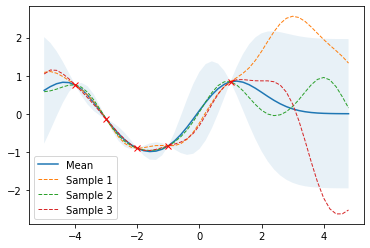

```python
# Noise free training data
X_train = np.array([-4, -3, -2, -1, 1]).reshape(-1, 1)
Y_train = np.sin(X_train)

# Define the testing space we want to probe
X = np.arange(-5, 5, 0.2).reshape(-1, 1)

# Compute mean and covariance of the posterior predictive distribution
mu_s, cov_s = posterior_predictive(X, X_train, Y_train)

samples = np.random.multivariate_normal(mu_s.ravel(), cov_s, 3)
# get rid of the different samples
plot_gp(mu_s, cov_s, X, X_train=X_train, Y_train=Y_train, samples=samples)
```

## Consequences of GP

- Gaussian Process Regression gives us a way to quantify uncertainty
- We use the covariance matrix to find the standard deviation
  - High deviation -> High uncertainity
- How is this useful?
  - We exploit the tradeoff between uncertainty and certainty
  - This exploitation is the basis of Bayesian Optimization!

## Bayesian Optimization basics

- Making smart setting choices

[figure not shown]

- Based on initial or procured experimental datapoints, we use Bayesian Optimization to find new set of parameters which can help us direct our next set of experiments
- These points can be based either on the maximum uncertainity or maximum potential reward: this is typically referred to as a trade off between exploitation and exploration.

## Bayesian Optimization

- Sequential design strategy for global optimization of black-box functions
- Usually employed to optimize expensive-to-evaluate functions
- Using information / data available to us to navigate the available exploration space
- This is very useful for experimentalists where performing every experiment is time consuming

### Let's define a few terms!

- Bayesian Optimization builds a probability model of the **objective function** to find the global optimimum in a minimum number of steps
- The **objective function** is the black-box-function we want to optimize $\rightarrow$ mapping experimental conditions to experimental outputs. (We will discuss this further)
- Bayesian optimization incorporates a prior belief about the objective function *f* and updates the prior with samples drawn from *f* to get a posterior that better approximates *f*.

[figure not shown]

## Surrogate models & Uncertainty:

- Given the input data, we want to find the points of the input space which we expect to be highly rewarding.
- This can be done with using uncertainities:
  - **Exploration**: Exploring regions of inputs where we have higher uncertainty
  - **Exploitation**: Choosing points in regions where we are more certain to get guarranted rewards
- Mathematically, uncertainity is quantified using probability. Gaussian Process (GP) helps us model uncertainties
- Such a model is called a **Surrogate Model**
- **Acqusition function** is the way we specify the trade-off between exploration and exploitation

[figure not shown]

- The blue region indicates the uncertainty of the output space.

### Acquisition function:

- Bayesian optimization uses an acquisition function that directs sampling to areas where an improvement over the current best observation is likely.
- Popular acquisition functions: maximum probability of improvement (MPI), expected improvement (EI)

$$MPI(x) = \psi(\frac{\mu(x)-f(x^+)-\xi}{\sigma(x)})$$$$EI(x) = (\mu(x)-f(x^+)-\xi) \psi(\frac{\mu(x)-f(x^+)-\xi}{\sigma(x)}) + \sigma(x) \phi(\frac{\mu(x)-f(x^+)-\xi}{\sigma(x)})$$$$UCB(x) = \mu(x) + \beta \sigma(x)$$

where $\mu(x)$ is the mean function, $\sigma(x)$ is the variance, $\beta$ & $\xi$ are parameters controlling degree of exploration and $\psi(z)$ \& $\phi(z)$ is cumulative distribution function of a standard Gaussian distribution $N(0,1)$

### The Bayesian Optimization Framework:

- The Bayesian optimization procedure is as follows. For t=1,2,… repeat:
  - Find the next sampling point $x_t$ by optimizing the acquisition function over the GP: $x_t=argmax_xu(x|D_{1:t−1})$
  - Obtain a possibly noisy sample $y_t=f(x_t)+ϵ_t$ from the objective function f.
  - Add the sample to previous samples $D_{1:t}=\{D_{1:t−1},(x_t,y_t)\}$ and update the GP.

## Bayesian Optimization in Python

- Several libraries are available for performing bayesian optimization in Python
- We will use two libraries: scikit-learn and bayesian-optimization
- We will use scikit-learn for developing surrogate model; and the bayesian-optimization library for the optimization
- Lets install the required packages:

```python
!pip install bayesian-optimization
!pip install scikit-learn
```

### Let's solve a dummy problem with Bayesian Optimization

- We will choose a dummy function which we will probe
- Using Bayesian Optimization, we will try to find the point where it achieves the maximum
- black_box_function can return a truth table as well
  - This is what you will use for experimental data!

```python
def black_box_function(x, y):
    """Function with unknown internals we wish to maximize.
    In our case, this will be a simple ML model trained on experimental datapoints
    """

    if x==2.0 and y==3.0:
        return 0.8
    elif x==3.0 and y==3.2:
        return 0.83
```

### Let's introduce the BayesianOptimization object

```python
from bayes_opt import BayesianOptimization

# Bounded region of parameter space
pbounds = {'x': (1, 4), 'y': (0, 4)}

optimizer = BayesianOptimization(
    f=black_box_function,
    pbounds=pbounds
)
```

- f is the function to be optimized and expensive to compute
- pbounds: bounds on the parameters

### Let's perform the maximize operation

```python
optimizer.maximize(
    init_points=2,
    n_iter=3,
)
```

[output not shown]

- init_points: Represent number of steps of random experiments we want to perform
- n_iter: Steps of Bayesian Optimization we want to perform

### Let's look at the point where we are expect to perform our next experiment

```python
print(optimizer.max)
```

[output not shown]

### What if we don't want to train an ML model ?

- We can specify the points we want the framework to probe
- Our black_box_function can then provide the experimental data we already know

```python
optimizer.probe(
    params={"x": 2, "y": 3},
    lazy=True,
)

optimizer.probe(
    params=[3, 3.2],
    lazy=True,
)

# Will probe only the two points specified above
optimizer.maximize(init_points=0, n_iter=0)
```

```
|   iter    |  target   |     x     |     y     |
-------------------------------------------------
|  1        |  0.8      |  2.0      |  3.0      |
|  2        |  0.83     |  3.0      |  3.2      |
=================================================
```

### Including several pre-defined points from experiments

```python
vals = [[0.5,0.6],[0.9,0.4],[0.3,0.88]]

for i in vals:
    optimizer.probe( params=i,lazy=True,)


# Will probe only the two points specified above
optimizer.maximize(init_points=0, n_iter=2)
```

[output not shown]

### Saving the trained models for later usage

- Will save things in a .json format

```python
from bayes_opt.logger import JSONLogger
from bayes_opt.event import Events

logger = JSONLogger(path="./logs.json")
optimizer.subscribe(Events.OPTIMIZATION_STEP, logger)

# Results will be saved in ./logs.json
optimizer.maximize(
    init_points=2,
    n_iter=3,
)
```

### Loading the progress

```python
from bayes_opt.util import load_logs


new_optimizer = BayesianOptimization(
    f=black_box_function,
    pbounds={"x": (-2, 2), "y": (-2, 2)},
    verbose=2,
    random_state=7,
)

# New optimizer is loaded with previously seen points
load_logs(new_optimizer, logs=["./logs.json"]);
```

### How do we deal with discrete variables?

- Till now all the exercises were with continuous variables
- There is no direct way to handle discrete variables but we can do some tricks

```python
def function_to_be_optimized(x, y, w):
    d = int(w)
    return ((x + y + d) // (1 + d)) / (1 + (x + y) ** 2)
```

```python
function_to_be_optimized(1,2,3)
```

```
0.1
```

```python
optimizer = BayesianOptimization(f=function_to_be_optimized, pbounds={'temperature': (100, 1000), 'y': (-10, 10), 'w': (0, 5)})
optimizer.maximize(init_points=2,n_iter=2)
```

[output not shown]

### Can we modify the hyper-parameters of the underlying GP?

- The answer is yes; it can be done while calling the maximize routine
- The backend uses [sklearn's Gaussian Process Regressor](https://scikit-learn.org/stable/modules/generated/sklearn.gaussian_process.GaussianProcessRegressor.html)
- So, any parameter that is supported there can be given as an input

[output not shown]

# Thank you!

## Appendix:

- Bayesian Neural Networks (BNNs)

### Bayesian Neural Networks (BNNs)

- BNN is a neural network with a prior distribution on its weights
- The known data is used to update the posterior given our prior beliefs about the weights
- Standard NN training via optimization is equivalent to maximum likelihood estimation (MLE) for the weights

## Maths of BNNs:

- We are given data set $\{(x_n,y_n)\}$, where each data point comprises of features $x_n \in R^D$ and output $y_n \in R$.
- Define the likelihood for each data point as, $$p(y_n|w,x_n,\sigma^2) = N(y_n|h(x_n;w),\sigma^2)$$ where $h(\cdot)$ denotes a neural network whose weights and biases form the latent variables **w**. Assume $\sigma^2$ is known.
- We also define the prior on the weights and biases w to be standard normal: $$p(w) = N(0,1)$$
- A very easy way to run a BNN is through [Edward library](http://edwardlib.org/tutorials/bayesian-neural-network)